# 2019 Three Infections

antoine.bridier-nahmias@inserm.fr

09/06/2020

Results will be compiled here:

# Packages and data loading

## Packages

```r
library(readr)
library(dplyr)
library(tidyr)
library(stringr)
library(DT)
library(kableExtra)
library(ggplot2)
library(cowplot)
library(ggrepel)
library(ggtree)
library(survival)
library(survminer)
library(gggenes)
library(ggnewscale)
# library()
source("./phylo_funk.r")
theme_set(theme_cowplot())
```

## Data

The mutations are all presented in a data_frame (tsv) containing the following variables (most should be self explanatory):

- **patient:** patient id;
- **subclon:** sub-clone id
- **aa_new_seq:**
- **aa_position:**
- **aa_ref_seq:**
- **codon_new_seq:**
- **codon_ref_seq:**
- **seq_id:** contig number (might not be kept in the final table).
- **mut_size**
- **position**
- **gene_name**
- **gene_position**
- **gene_product**
- **snp_type**: One of `synonymous, nonsynonymous, nonsense, intergenic`.
- **type**: One of `SNP, DEL, INS, SUB`.
- **synonymous**: Is the substitution synonymous (`TRUE/FALSE`)?
- **Remarks**
- **phase_disrupt**: Does the mutation disrupt an ORF: (`TRUE/FALSE`)?

```r
all_mut =
  read_tsv(file = "../data/variants/tables/all_mutations_final.tsv")

# all isolates
isolates <- data.frame(stringsAsFactors = F,
  patient_11 = c("4248", "4254", "4249", "4252", "4253", "4251", "4250"),
  patient_13 = c("4428", "4434", "4431", "4433", "4432", "4430", "4429"),
  patient_17 = c("5-36", "5-40", "5-41", "5-38", "5-39", "5-34", "5-35"))

# mutators isolates
mutators <- c(p_11_mutator = "4254",
              p_13_mutator = "4433",
              p_17_mutator = "5-36")
```

# Exploratory data analysis

## Reader Friendly table

We might want to compute the following in order to *invert* mutations present in more than half the subclons.

`tot_subclon` : total number of subclon by patient (always 7 but we compute it nevertheless) `in_n_subclon` : For a specific mutation, in how many sublcon it is found in a patient

```r
friendly_all_mut <-
all_mut %>%
  rowwise() %>%
  mutate(subclon_  = str_split(string = subclon, pattern = "\\|", simplify = F)) %>%
  mutate(subclon__ = list(isolates[ ,patient])) %>%
  mutate(reverse = length(subclon_) > ( length(subclon__) / 2)) %>%
  mutate(isolates = if_else(condition = reverse,
      true = list(subclon__[! subclon__ %in% subclon_]),
      false = list(subclon_))) %>%
  mutate(isolates = str_flatten(isolates, collapse = "|")) %>%
  select(-c("subclon", "subclon_", "subclon__", "reverse", "codon_new_seq", "codon_ref_seq", "seq_id")) %>%
  select(patient, isolates, everything()) %>%
  datatable(caption = "Mutations Table",
            filter = "top",
            class = "cell-border stripe compact",
            extensions = c("Buttons", "FixedHeader"),
            options = list( dom = 'lfrtip B',
                            buttons = c("copy","csv"),
                            fixedHeader = TRUE))
friendly_all_mut
```

|  | patient | isolates | aa_new_seq | aa_position | aa_ref_seq | mut_size | position | gene_name | gene_position | gene_product | snp_type | type | synonymous | Remarks | phase_disrupt | plasmidic |
| --- | --- | --- | --- | --- | --- | --- | --- | --- | --- | --- | --- | --- | --- | --- | --- | --- |
| 1 | patient_11 | 4248 | * | 63 | E | 1 | 757867 | epsD | 187 | Putative glycosyltransferase EpsD | nonsense | SNP | False |  | True |  |
| 2 | patient_11 | 4254 | * | 99 | Q | 1 | 1309182 | ynaA_2 | 295 | Rac prophage, predicted tail protein | nonsense | SNP | False |  | True |  |
| 3 | patient_11 | 4254 | A | 179 | T | 1 | 6362 | fimH | 535 | minor fimbrial subunit, D-mannose specific adhesin | nonsynonymous | SNP | False |  |  |  |
| 4 | patient_11 | 4254 | A | 46 | T | 1 | 709158 | JJGPNMLM_03777 | 136 | hypothetical protein | nonsynonymous | SNP | False |  |  |  |
| 5 | patient_11 | 4250 | D | 195 | N | 1 | 1168954 | mreB | 583 | longitudinal peptidoglycan synthesis/chromosome segregation-directing complex | nonsynonymous | SNP | False |  |  |  |
| 6 | patient_11 | 4254 | E | 470 | E | 1 | 1200488 | prpD | 1410 | 2-methylcitrate dehydratase | synonymous | SNP | True |  |  |  |
| 7 | patient_11 | 4254 | G | 73 | G | 1 | 604275 | asnC | 219 | AsnC-L-asparagine | synonymous | SNP | True |  |  |  |
| 8 | patient_11 | 4249 | K | 62 | Q | 1 | 6011 | fimH | 184 | minor fimbrial subunit, D-mannose specific adhesin | nonsynonymous | SNP | False |  |  |  |
| 9 | patient_11 | 4250 | L | 150 | V | 1 | 6275 | fimH | 448 | minor fimbrial subunit, D-mannose specific adhesin | nonsynonymous | SNP | False |  |  |  |
| 10 | patient_11 | 4254 | L | 23 | L | 1 | 1619414 | lgt | 69 | phosphatidylglycerol-prolipoprotein diacylglyceryl transferase | synonymous | SNP | True |  |  |  |

[output cut: 305 more lines]

```r
DT::saveWidget(widget = friendly_all_mut, file = "./2020-all_mutations.html")
```

## Basic figures

Here are a few simple figures (mutations counts) characterizing the data:

```r
indel_threshold <- 50 # from Gonzalez et al., 2007

all_mut %>%
  mutate(patient = "all") %>%
  rbind(all_mut) %>%
  group_by(patient) %>%
  mutate(n_mut_total = n()) %>%
  # SNP
  mutate(n_SNP_total = sum(type == "SNP", na.rm = TRUE)) %>%
  mutate(n_SNP_synonymous = sum(snp_type == "synonymous", na.rm = TRUE)) %>%
  mutate(n_SNP_nonsynonymous = sum(snp_type == "nonsynonymous", na.rm = TRUE)) %>%
  mutate(n_SNP_nonsense = sum(snp_type == "nonsense", na.rm = TRUE)) %>%
  mutate(n_SNP_intergenic = sum(snp_type == "intergenic", na.rm = TRUE)) %>%
  # INDEL
  mutate(n_INDEL_small_total = sum(type %in% c("INS", "DEL") & mut_size < indel_threshold)) %>%
  mutate(n_INDEL_small_intergenic = sum(type %in% c("INS", "DEL") & mut_size < indel_threshold & str_detect(string = gene_position, pattern = "^intergenic.*"))) %>%
  mutate(n_INDEL_small_frameshift = sum(type %in% c("INS", "DEL") & mut_size < indel_threshold & mut_size %% 3 != 0)) %>%
  mutate(n_INDEL_small_noframeshift = sum(type %in% c("INS", "DEL") & mut_size < indel_threshold & mut_size %% 3 == 0)) %>%
  mutate(n_INDEL_large_total = sum(type %in% c("INS", "DEL") & mut_size > indel_threshold)) %>%
  select(patient, starts_with(match = "n_")) %>%
  slice(1) %>%
  identity() -> basic_figures

# basic_figures
basic_figs <-
basic_figures %>%
  select(patient, n_mut_total, n_INDEL_large_total, n_INDEL_small_intergenic,
         n_SNP_intergenic, n_INDEL_small_noframeshift, n_INDEL_small_frameshift,
         n_SNP_nonsense, n_SNP_nonsynonymous,
         n_SNP_synonymous) %>%
  kable(col.names = rep("", ncol(.))) %>%
    kable_styling(bootstrap_options = c("striped", "bordered"), full_width = TRUE) %>%
    add_header_above(header = c("Patient" = 1, "Total" = 1, "Large del" = 1,
                                 "Indel" = 1, "SNP" = 1, "In frame" = 1,
                                "Frameshift" = 1,"NonSens" = 1,
                                "NonSynonymous" = 1, "Synonymous" = 1)) %>%
    add_header_above(header = c(" " = 3, "Intergenic" = 2,"INDEL" = 2, "SNP" = 3)) %>%
    add_header_above(header = c(" " = 5, "Genic" = 5))

mut_no_mut <-
  all_mut %>%
  group_by(patient) %>%
  mutate(total_mut = n()) %>%
  filter(subclon %in% c("4254", "4433", "5-36")) %>%
  mutate(mutator_mut = n()) %>%
  slice(1) %>%
  select(patient, total_mut, mutator_mut)

mut_no_mut_size_1 <-
  all_mut %>%
  group_by(patient) %>%
  filter(mut_size == 1) %>%
  mutate(total_mut = n()) %>%
  filter(subclon %in% c("4254", "4433", "5-36")) %>%
  mutate(mutator_mut = n()) %>%
  slice(1) %>%
  select(patient, total_mut, mutator_mut)

basic_figs
```

| Patient | Total | Large del | Intergenic Indel | Intergenic SNP | Genic INDEL In frame | Genic INDEL Frameshift | Genic SNP NonSens | Genic SNP NonSynonymous | Genic SNP Synonymous |
| --- | --- | --- | --- | --- | --- | --- | --- | --- | --- |
| all | 315 | 43 | 14 | 33 | 6 | 47 | 12 | 136 | 34 |
| patient_11 | 36 | 5 | 0 | 4 | 1 | 4 | 2 | 15 | 5 |
| patient_13 | 65 | 3 | 4 | 3 | 2 | 19 | 4 | 27 | 7 |
| patient_17 | 214 | 35 | 10 | 26 | 3 | 24 | 6 | 94 | 22 |

```r
mut_no_mut
```

| patient | total_mut | mutator_mut |
| --- | --- | --- |
| patient_11 | 36 | 17 |
| patient_13 | 65 | 22 |
| patient_17 | 214 | 103 |

```r
# write_tsv(x = basic_figs, path = "../docs/Tables/mut_types.tsv")
```

Table 1: Mutationnal events occuring in *E. coli* clones isolated from three extra-intestinal infections. INDEL larger than 50 were considered as large.

## Convergent evolution

Intra- and inter-host: We count as convergent mutation an independent mutation in the same gene. Working on operon is too convoluted to be easily computed.

We’ll start by creating the table for SNP mutations only and then update the counts with results from the deletion and maybe, sadly, a manual curation step.

The gene names finishing in the `"_[1-9]"` pattern are potential duplications annotated by prokka. Since they are the same genes, we’ll group them together by eliminating the pattern from `gene_name`.

`n_time_in_patient` : For a gene, how many times it is mutated per patient `in_n_patients` : For a mutated gene, in how many different patient can it be found

```r
# Identifying convergence in non intergenic SNPs and small INDELs

large_del_inter_pattern <- "[–\\/\\[]" # the / is a sign of intergenic_mutation

all_mut %>%
  mutate(gene_name = str_replace(string = gene_name,
                                 pattern = "(.*)_[0-9]{1,2}$",
                                 replacement = "\\1")) %>%
  filter((type == "SNP" & snp_type != "intergenic") |
           (type %in% c("DEL", "INS")) &
           !str_detect(string = gene_name, pattern = large_del_inter_pattern)) %>%
  select(patient, gene_name, gene_product, type) -> convergent_snp_long



# Identifying convergence in large deletions:
large_deletion_pattern <- "[–\\[]" # the / is in fact a sign of intergenic_mutation
all_mut %>%
  filter(str_detect(string = gene_name, pattern = large_deletion_pattern)) %>%
  identity() -> del_mut

convergent_del <- tibble(patient = "", gene_name = "")
for (i in 1:nrow(del_mut)) {
  curr_del <- del_mut[i, ]
  out_del <- tibble(patient = curr_del$patient, gene_name = curr_del$gene_product)
  convergent_del <- rbind(convergent_del, out_del)
}
convergent_del <- convergent_del[2:nrow(convergent_del),]


convergent_del %>%
  mutate(del_id = paste0("DEL_",row_number())) %>%
  mutate(gene_name = str_remove_all(string = gene_name, pattern = "[\\[\\]]")) %>%
  mutate(gene_name = str_remove_all(string = gene_name, pattern = "<.*R>")) %>%
  mutate(gene_name = str_remove_all(string = gene_name, pattern = "<\\/i>")) %>%
  separate(col = gene_name, into = paste0("A", 1:50), sep = ",") %>%
  gather(key = "useless", value = "gene_name", -patient, -del_id) %>%
  mutate(gene_name = trimws(gene_name)) %>%
  mutate(gene_name = str_replace(string = gene_name,
                                 pattern = "(.*)_[0-9]{1,2}$",
                                 replacement = "\\1")) %>%
  mutate(gene_name = str_replace_all(string = gene_name,
                                 pattern = "\u2011",
                                 replacement = "-")) %>% # 0x2011 is the HEX for "non-breaking hyphen"

  filter(!is.na(gene_name)) %>%
  mutate(gene_product = "" , type = "Large_DEL") %>%
  # Eliminating 'duplicated' genes found in the same deletion e.g ynfK
  group_by(del_id, gene_name) %>%
  slice(1) %>%
  ungroup() %>%
  select(-useless, -del_id) %>%
  identity() -> convergent_del_long
```

```
Expected 50 pieces. Additional pieces discarded in 3 rows [7, 29, 31].Expected 50 pieces. Missing pieces filled with `NA` in 37 rows [1, 2, 3, 4, 5, 6, 8, 9, 10, 11, 12, 13, 14, 15, 16, 17, 18, 19, 20, 21, ...].
```

```r
convergent_all_long <-
  rbind(convergent_snp_long, convergent_del_long)


convergent_all_long %>%
  # mutate(mut_id = paste0("mut", 1:n())) %>%
  group_by(gene_name) %>%
  mutate(in_n_patient = length(unique(patient))) %>%
  group_by(patient, gene_name) %>%
  mutate(n_time_in_patient = n()) %>%
  ungroup() %>%
  # summarize
  group_by(gene_name) %>%
  mutate_at(.vars = c("gene_product", "type"),
            .funs = function(x) paste0(unique(x), collapse = "; ")) %>%
  ungroup() %>%
  group_by(patient, gene_name) %>%
  slice(1) %>%
  ungroup() %>%
  # filter out non convergent mutations
  filter(in_n_patient > 1 | n_time_in_patient > 1) %>%
  identity() -> convergent_all_long



convergent_all_long %>%
  select(patient, gene_name, gene_product, type, n_time_in_patient) %>%
  spread(key = patient, value = n_time_in_patient, fill = 0) %>%
  mutate(total = patient_11 + patient_13 + patient_17) %>%
  # almost 100 mut are convergent only in patient_17 large deletions
  # filtering out all mutation (type == "Large_DEL") only present in one patient.
  rowwise() %>%
  filter(!(type == "Large_DEL" & (sum(patient_11 != 0, patient_13 != 0, patient_17 != 0) == 1))) %>%
  ungroup() %>%
  arrange(desc(total)) %>%
  identity() -> convergent_all

# unwanted_genes <- c("insC.*","insA.*", "ydf.*", "dic.*", "rzp.*", "yda.*","FOBKHAMO.*", "JJGPNMLM.*")
unwanted_genes <- c("insC.*","insA.*", "ydf.*", "dic.*", "rzp.*", "yda.*")
is_wanted <-
  sapply(X = convergent_all$gene_name,
         FUN = function(x) sum(str_detect(string = x, pattern = unwanted_genes)) == 0)

convergent_all %>%
  filter(is_wanted) -> convergent_all_filtered

# Manually adding some gene description
descriptions <- list(
  mutS = "MutHLS complex, methyl-directed mismatch repair",
  pphB = "protein-tyrosine-phosphatase / phosphoprotein phosphatase",
  ygbI = "putative DNA-binding transcriptional regulator, DEOR-type"
)

for (i in 1:nrow(convergent_all_filtered)) {
  if (convergent_all_filtered$gene_product[i] == "") {
    convergent_all_filtered$gene_product[i] <-
      descriptions[[convergent_all_filtered$gene_name[i]]]
  }
}


# Final printing
kable(convergent_all_filtered, caption = "Convergence") %>%
  kable_styling(bootstrap_options = c("bordered"), full_width = FALSE)
```

Convergence

| gene_name | gene_product | type | patient_11 | patient_13 | patient_17 | total |
| --- | --- | --- | --- | --- | --- | --- |
| rbsR | RbsR DNA-binding transcriptional repressor | DEL; SNP; INS | 2 | 6 | 1 | 9 |
| putA | fused PutA transcriptional repressor / proline dehydrogenase / 1-pyrroline-5-carboxylate dehydrogenase; | SNP; Large_DEL | 0 | 4 | 4 | 8 |
| glpD | glycerol-3-phosphate dehydrogenase, aerobic | SNP; DEL | 0 | 6 | 1 | 7 |
| rpoS | RNA polymerase, sigma S (sigma 38) factor; rpoS; | SNP; DEL; Large_DEL | 2 | 3 | 1 | 6 |
| ydcI | putative transcriptional regulator LysR-type; | SNP; INS; Large_DEL | 0 | 0 | 6 | 6 |
| fimH | minor fimbrial subunit, D-mannose specific adhesin | SNP; DEL | 4 | 1 | 0 | 5 |
| acrB | AcrB RND-type permease; | SNP; DEL; Large_DEL | 2 | 1 | 1 | 4 |
| hupA | transcriptional dual regulator HU-alpha (HU-2) | DEL; SNP | 0 | 1 | 3 | 4 |
| putP | proline:Na+ symporter; | SNP; Large_DEL | 0 | 0 | 4 | 4 |
| aldA | aldehyde dehydrogenase A, NAD-linked; | SNP; Large_DEL | 0 | 0 | 3 | 3 |
| fliC | flagellar biosynthesis, flagellin, filament structural protein | SNP | 1 | 2 | 0 | 3 |
| fnr | FNR DNA-binding transcriptional dual regulator; | SNP; Large_DEL | 0 | 2 | 1 | 3 |
| frsA | fermentation/respiration switch protein; | SNP; Large_DEL | 0 | 0 | 3 | 3 |
| glnL | NtrB; | SNP; Large_DEL | 0 | 2 | 1 | 3 |
| miaA | tRNA(i6A37) synthase; | SNP; INS; Large_DEL | 0 | 3 | 0 | 3 |
| paoC | aldehyde dehydrogenase: molybdenum cofactor-binding subunit; | SNP; Large_DEL | 0 | 0 | 3 | 3 |
| tehA | TehA TDT transporter; | SNP; Large_DEL | 0 | 0 | 3 | 3 |
| actP | acetate / glycolate transporter; | SNP; Large_DEL | 0 | 0 | 2 | 2 |
| agp | 3-phytase / glucose-1-phosphatase; | SNP; Large_DEL | 0 | 0 | 2 | 2 |
| alaE | L-alanine exporter; | DEL; Large_DEL | 0 | 0 | 2 | 2 |
| araA | L-arabinose isomerase monomer; | SNP; Large_DEL | 0 | 1 | 1 | 2 |
| cueO | multicopper oxidase with role in copper homeostasis | INS; SNP | 1 | 0 | 1 | 2 |
| dacA | D-alanyl-D-alanine carboxypeptidase, fraction A, penicillin-binding protein 5 | INS | 0 | 0 | 2 | 2 |
| ecpD | hypothetical protein; | SNP; Large_DEL | 0 | 1 | 1 | 2 |
| flhA | flagellar biosynthesis protein FlhA; | INS; Large_DEL | 0 | 1 | 1 | 2 |
| FOBKHAMO_04756 | hypothetical protein | SNP | 0 | 0 | 2 | 2 |
| FOBKHAMO_04764 | hypothetical protein; | SNP; Large_DEL | 0 | 0 | 2 | 2 |
| FOBKHAMO_04776 | hypothetical protein; | DEL; Large_DEL | 0 | 0 | 2 | 2 |
| fryA | fused predicted PTS system enzymes: Hpr component, enzyme I component, enzyme IIA component; | SNP; Large_DEL | 0 | 0 | 2 | 2 |
| ilvB | acetohydroxybutanoate synthase / acetolactate synthase | SNP | 0 | 1 | 1 | 2 |
| mreB | longitudinal peptidoglycan synthesis/chromosome segregation-directing complex | SNP | 1 | 0 | 1 | 2 |
| mscK | potassium dependent mechanosensitive channel MscK; | SNP; Large_DEL | 1 | 0 | 1 | 2 |
| mutS | MutHLS complex, methyl-directed mismatch repair | Large_DEL | 1 | 0 | 1 | 2 |
| pphB | protein-tyrosine-phosphatase / phosphoprotein phosphatase | Large_DEL | 1 | 0 | 1 | 2 |
| rpsH | 30S ribosomal subunit protein S8 | SNP | 0 | 0 | 2 | 2 |
| sstT | serine / threonine:Na+ symporter | SNP | 0 | 0 | 2 | 2 |
| tbpA | thiamin ABC transporter - periplasmic binding protein; | SNP; Large_DEL | 0 | 0 | 2 | 2 |
| thiP | thiamin ABC transporter - membrane subunit; | DEL; Large_DEL | 0 | 0 | 2 | 2 |
| yafL | putative lipoprotein and C40 family peptidase; | SNP; Large_DEL | 0 | 0 | 2 | 2 |
| ydeO | YdeO DNA‑binding transcriptional dual regulator; | DEL; Large_DEL | 0 | 0 | 2 | 2 |
| yedW | putative DNA-binding response regulator in two-component system with YedV; | SNP; Large_DEL | 1 | 0 | 1 | 2 |
| yfeO | putative ion channel protein; | SNP; Large_DEL | 0 | 0 | 2 | 2 |
| ygbI | putative DNA-binding transcriptional regulator, DEOR-type | Large_DEL | 1 | 0 | 1 | 2 |
| ynfF | oxidoreductase subunit; | SNP; Large_DEL | 1 | 0 | 1 | 2 |

```r
write_tsv(x = convergent_all_filtered, path = "../docs/Tables/convergence.tsv")
```

```r
# convergence within
convergent_all_filtered %>%
  select_at(dplyr::vars(starts_with("patient"))) %>%
  mutate_all(.funs = function(x) sum(x[x > 1])) %>%
  slice(1) %>%
  t() %>%
  as.data.frame() %>%
  dplyr::rename(convergent = V1) %>%
  mutate(patient = rownames(.)) %>%
  select(patient, convergent) %>%
  left_join(y = mut_no_mut, by = c("patient")) %>%
  mutate(perc_conv_tot = round(convergent / total_mut, 2)) %>%
  mutate(perc_conv_tot_nomut = round(convergent / (total_mut - mutator_mut), 2)) %>%
  identity() -> converge_within

# convergence between
convergent_all_filtered %>%
  select(-gene_product, -type, -total) %>%
  mutate_at(.vars = dplyr::vars(starts_with("patient")),
            .funs = list(conv = function(x) x > 0)) %>%
  mutate(n_convergent = rowSums(select(., ends_with("_conv")))) %>%
  select_at(.vars = dplyr::vars(-ends_with("_conv"))) %>%
  filter(n_convergent > 1) -> converge_between_full


convergent_all_filtered %>%
  select_at(dplyr::vars(starts_with("patient"))) %>%
  rowwise() %>%
  mutate(between = sum(patient_11 == 0,patient_13 == 0, patient_17 == 0) < 2) %>%
  ungroup() %>%
  filter(between == TRUE) %>%
  select(-between) %>%
  summarise_all(sum) %>%
  t() %>%
  as.data.frame() %>%
  dplyr::rename(convergent = V1) %>%
  mutate(patient = rownames(.)) %>%
  select(patient, convergent) %>%
  left_join(y = mut_no_mut, by = c("patient")) %>%
  mutate(perc_conv_tot = round(convergent / total_mut, 2)) %>%
  mutate(perc_conv_tot_nomut = round(convergent / (total_mut - mutator_mut), 2)) %>%
  identity() -> converge_between

# Part of convergence due to the mutators
all_mut %>%
  filter(subclon %in% mutators) %>%
  filter(gene_name %in% convergent_all_filtered$gene_name |
           gene_product %in% convergent_all_filtered$gene_name) %>%
  identity() -> convergence_mutators

# Pretty print
kable(converge_within, caption = "Convergence Within Patients") %>%
  kable_styling(bootstrap_options = c("bordered", "striped"), full_width = FALSE)
```

Convergence Within Patients

| patient | convergent | total_mut | mutator_mut | perc_conv_tot | perc_conv_tot_nomut |
| --- | --- | --- | --- | --- | --- |
| patient_11 | 10 | 36 | 17 | 0.28 | 0.53 |
| patient_13 | 28 | 65 | 22 | 0.43 | 0.65 |
| patient_17 | 59 | 214 | 103 | 0.28 | 0.53 |

```r
kable(converge_between, caption = "Convergence Between Patients") %>%
  kable_styling(bootstrap_options = c("bordered", "striped"), full_width = FALSE)
```

Convergence Between Patients

| patient | convergent | total_mut | mutator_mut | perc_conv_tot | perc_conv_tot_nomut |
| --- | --- | --- | --- | --- | --- |
| patient_11 | 19 | 36 | 17 | 0.53 | 1.00 |
| patient_13 | 32 | 65 | 22 | 0.49 | 0.74 |
| patient_17 | 25 | 214 | 103 | 0.12 | 0.23 |

```r
NA
```

# Population genetics calculations

## Thetas and Tajima’s D

Here is calculated (excluding the mutators):

- `watt` : $\theta _{Watterson}$ or $S$, the number of segregating sites
- `pi` : ${\pi}$, the pairwise differences between subclones
- `D` : $\frac{d}{\sqrt{\hat{V}_{d}}}$, Tajima’s D with $d={\pi} - \theta _{W}$

```r
source("./make_variants.r")
p_watt <- sapply(FUN = get, X = apropos(what = "^p_.._watt$"))

p_pi <- sapply(FUN = get, X = apropos(what = "^p_.._pi$"))

p_D <-  as.data.frame(sapply(FUN = get, X = apropos(what = "^p_.._D$")))
val <- rownames(p_D)
p_D %>%
  mutate_all(as.numeric) %>%
  mutate(val = val) %>%
  select(val, everything()) -> p_D

p_watt
```

```
p_11_watt p_13_watt p_17_watt
 6.131387 11.386861 26.938776
```

```r
p_pi
```

```
  p_11_pi   p_13_pi   p_17_pi
 4.866667  9.066667 20.476190
```

```r
kable(p_D) %>% kable_styling(full_width = FALSE)
```

| val | p_11_D | p_13_D | p_17_D |
| --- | --- | --- | --- |
| D | -1.2666043 | -1.2852268 | -1.3937612 |
| Pval.normal | 0.2052968 | 0.1987130 | 0.1633897 |
| Pval.beta | 0.2162157 | 0.2026853 | 0.1532077 |

## Ka/Ks | dNdS

Creating the correct mutation format for O. Tenaillon’s perl script. The header is self explanatory: S = synonymous NS = non-synonymous; the letters represent the substitution. **S_AT_CG S_AT_GC S_AT_TA S_CG_GC S_CG_TA S_GC_TA NS_AT_CG NS_AT_GC NS_AT_TA NS_CG_GC NS_CG_TA NS_GC_TA**

We will exclude the mutator from these computations.

```r
all_mut %>%
  filter(!(subclon %in% mutators)) %>%
  # finding the nucleotides substituted in each SNP
  filter(type == "SNP", snp_type == "synonymous" | snp_type == "nonsynonymous" ) %>%
  rowwise() %>%
  mutate(nuc_ref = codon_compare(cod_ref = codon_ref_seq, cod_mut = codon_new_seq)[[1]]) %>%
  mutate(nuc_mut = codon_compare(cod_ref = codon_ref_seq, cod_mut = codon_new_seq)[[2]]) %>%
  ungroup() %>%
  # Counting all 12 possible mutations types
  # Synonymous
  mutate(S_AT_CG = synonymous == TRUE & ((nuc_ref == "A" & nuc_mut == "C") | (nuc_ref == "T" & nuc_mut == "G"))) %>%
  mutate(S_AT_GC = synonymous == TRUE & ((nuc_ref == "A" & nuc_mut == "G") | (nuc_ref == "T" & nuc_mut == "C"))) %>%
  mutate(S_AT_TA = synonymous == TRUE & ((nuc_ref == "A" & nuc_mut == "T") | (nuc_ref == "T" & nuc_mut == "A"))) %>%
  mutate(S_CG_GC = synonymous == TRUE & ((nuc_ref == "C" & nuc_mut == "G") | (nuc_ref == "G" & nuc_mut == "C"))) %>%
  mutate(S_CG_TA = synonymous == TRUE & ((nuc_ref == "C" & nuc_mut == "T") | (nuc_ref == "G" & nuc_mut == "A"))) %>%
  mutate(S_GC_TA = synonymous == TRUE & ((nuc_ref == "G" & nuc_mut == "T") | (nuc_ref == "C" & nuc_mut == "A"))) %>%
  # Non synonymous
  mutate(NS_AT_CG = synonymous == FALSE & ((nuc_ref == "A" & nuc_mut == "C") | (nuc_ref == "T" & nuc_mut == "G"))) %>%
  mutate(NS_AT_GC = synonymous == FALSE & ((nuc_ref == "A" & nuc_mut == "G") | (nuc_ref == "T" & nuc_mut == "C"))) %>%
  mutate(NS_AT_TA = synonymous == FALSE & ((nuc_ref == "A" & nuc_mut == "T") | (nuc_ref == "T" & nuc_mut == "A"))) %>%
  mutate(NS_CG_GC = synonymous == FALSE & ((nuc_ref == "C" & nuc_mut == "G") | (nuc_ref == "G" & nuc_mut == "C"))) %>%
  mutate(NS_CG_TA = synonymous == FALSE & ((nuc_ref == "C" & nuc_mut == "T") | (nuc_ref == "G" & nuc_mut == "A"))) %>%
  mutate(NS_GC_TA = synonymous == FALSE & ((nuc_ref == "G" & nuc_mut == "T") | (nuc_ref == "C" & nuc_mut == "A"))) %>%
  # Summarizing
  group_by(patient) %>%
  select(patient,S_AT_CG:NS_GC_TA) %>%
  summarise_all(sum) %>%
  identity() -> all_mut_count

write_tsv(x = all_mut_count[1, 2:13], path = "../data/variants/tables/patient_11_kaks.input", col_names = FALSE)
write_tsv(x = all_mut_count[2, 2:13], path = "../data/variants/tables/patient_13_kaks.input", col_names = FALSE)
write_tsv(x = all_mut_count[3, 2:13], path = "../data/variants/tables/patient_17_kaks.input", col_names = FALSE)
```

The gff files had to be manually ‘decapitated and squished’: the header had to be removed and the genome was ‘squished’ into a unique contig with the gene positions corrected.

```r
calc_kaks <- FALSE

if (calc_kaks) {
  system("touch mock_mask")

  patient_11_kaks_command <-
    "perl ./kaks_OT/GenomeCompositionComputer_abn.pl ../data/reference/patient_11/annotation/patient_11_squished.gff ../data/variants/tables/patient_11_kaks.input ./mock_mask"
  # patient_11_kaks_out <- system(command = patient_11_kaks_command, intern = TRUE)
  # patient_11_kaks <- as.numeric(tail(patient_11_kaks_out, n = 1))
  patient_11_kaks <- 0

  patient_13_kaks_command <-
    "perl ./kaks_OT/GenomeCompositionComputer_abn.pl ../data/reference/patient_13/annotation/patient_13_squished.gff ../data/variants/tables/patient_13_kaks.input ./mock_mask"
  patient_13_kaks_out <- system(command = patient_13_kaks_command, intern = TRUE)
  patient_13_kaks <- as.numeric(tail(patient_13_kaks_out, n = 1))

  patient_17_kaks_command <-
    "perl ./kaks_OT/GenomeCompositionComputer_abn.pl ../data/reference/patient_17/annotation/patient_17_squished.gff ../data/variants/tables/patient_17_kaks.input ./mock_mask"
  patient_17_kaks_out <- system(command = patient_17_kaks_command, intern = TRUE)
  patient_17_kaks <- as.numeric(tail(patient_17_kaks_out, n = 1))


  system("rm mock_mask")
  system("rm ECBGenesCDS.txt")
  system("rm GenomeComposition.txt")
}

# Value from previous run:
patient_11_kaks <- "+ Inf"
patient_13_kaks <- 3.46
patient_17_kaks <- 5.09
```

Ka/Ks :

- Patient 11: + Inf
- Patient 13: 3.46
- Patient 17: 5.09

As an ‘exercise in style’ we will compute these Kaks for the mutator only:

```r
calc_kaks <- FALSE

if (calc_kaks) {

all_mut %>%
  filter((subclon %in% mutators)) %>%
  # finding the nucleotides substituted in each SNP
  filter(type == "SNP", snp_type == "synonymous" | snp_type == "nonsynonymous" ) %>%
  rowwise() %>%
  mutate(nuc_ref = codon_compare(cod_ref = codon_ref_seq, cod_mut = codon_new_seq)[[1]]) %>%
  mutate(nuc_mut = codon_compare(cod_ref = codon_ref_seq, cod_mut = codon_new_seq)[[2]]) %>%
  ungroup() %>%
  # Counting all 12 possible mutations types
  # Synonymous
  mutate(S_AT_CG = synonymous == TRUE & ((nuc_ref == "A" & nuc_mut == "C") | (nuc_ref == "T" & nuc_mut == "G"))) %>%
  mutate(S_AT_GC = synonymous == TRUE & ((nuc_ref == "A" & nuc_mut == "G") | (nuc_ref == "T" & nuc_mut == "C"))) %>%
  mutate(S_AT_TA = synonymous == TRUE & ((nuc_ref == "A" & nuc_mut == "T") | (nuc_ref == "T" & nuc_mut == "A"))) %>%
  mutate(S_CG_GC = synonymous == TRUE & ((nuc_ref == "C" & nuc_mut == "G") | (nuc_ref == "G" & nuc_mut == "C"))) %>%
  mutate(S_CG_TA = synonymous == TRUE & ((nuc_ref == "C" & nuc_mut == "T") | (nuc_ref == "G" & nuc_mut == "A"))) %>%
  mutate(S_GC_TA = synonymous == TRUE & ((nuc_ref == "G" & nuc_mut == "T") | (nuc_ref == "C" & nuc_mut == "A"))) %>%
  # Non synonymous
  mutate(NS_AT_CG = synonymous == FALSE & ((nuc_ref == "A" & nuc_mut == "C") | (nuc_ref == "T" & nuc_mut == "G"))) %>%
  mutate(NS_AT_GC = synonymous == FALSE & ((nuc_ref == "A" & nuc_mut == "G") | (nuc_ref == "T" & nuc_mut == "C"))) %>%
  mutate(NS_AT_TA = synonymous == FALSE & ((nuc_ref == "A" & nuc_mut == "T") | (nuc_ref == "T" & nuc_mut == "A"))) %>%
  mutate(NS_CG_GC = synonymous == FALSE & ((nuc_ref == "C" & nuc_mut == "G") | (nuc_ref == "G" & nuc_mut == "C"))) %>%
  mutate(NS_CG_TA = synonymous == FALSE & ((nuc_ref == "C" & nuc_mut == "T") | (nuc_ref == "G" & nuc_mut == "A"))) %>%
  mutate(NS_GC_TA = synonymous == FALSE & ((nuc_ref == "G" & nuc_mut == "T") | (nuc_ref == "C" & nuc_mut == "A"))) %>%
  # Summarizing
  group_by(patient) %>%
  select(patient,S_AT_CG:NS_GC_TA) %>%
  summarise_all(sum) %>%
  identity() -> mutator_mut_count

write_tsv(x = mutator_mut_count[1, 2:13], path = "../data/variants/tables/patient_11_mutator_kaks.input", col_names = FALSE)
write_tsv(x = mutator_mut_count[2, 2:13], path = "../data/variants/tables/patient_13_mutator_kaks.input", col_names = FALSE)
write_tsv(x = mutator_mut_count[3, 2:13], path = "../data/variants/tables/patient_17_mutator_kaks.input", col_names = FALSE)



  system("touch mock_mask")

  patient_11_mutator_kaks_command <-
    "perl ./kaks_OT/GenomeCompositionComputer_abn.pl ../data/reference/patient_11/annotation/patient_11_squished.gff ../data/variants/tables/patient_11_mutator_kaks.input ./mock_mask"
  patient_11_mutator_kaks_out <- system(command = patient_11_mutator_kaks_command, intern = TRUE)
  patient_11_mutator_kaks <- as.numeric(tail(patient_11_mutator_kaks_out, n = 1))


  patient_13_mutator_kaks_command <-
    "perl ./kaks_OT/GenomeCompositionComputer_abn.pl ../data/reference/patient_13/annotation/patient_13_squished.gff ../data/variants/tables/patient_13_mutator_kaks.input ./mock_mask"
  patient_13_mutator_kaks_out <- system(command = patient_13_mutator_kaks_command, intern = TRUE)
  patient_13_mutator_kaks <- as.numeric(tail(patient_13_mutator_kaks_out, n = 1))

  patient_17_mutator_kaks_command <-
    "perl ./kaks_OT/GenomeCompositionComputer_abn.pl ../data/reference/patient_17/annotation/patient_17_squished.gff ../data/variants/tables/patient_17_mutator_kaks.input ./mock_mask"
  patient_17_mutator_kaks_out <- system(command = patient_17_mutator_kaks_command, intern = TRUE)
  patient_17_mutator_kaks <- as.numeric(tail(patient_17_mutator_kaks_out, n = 1))


  system("rm mock_mask")
  system("rm ECBGenesCDS.txt")
  system("rm GenomeComposition.txt")
}

# Value from previous run:
patient_11_mutator_kaks <- 0.52
patient_13_mutator_kaks <- 0.93
patient_17_mutator_kaks <- 1.35
```

Mutators Ka/Ks :

- Patient 11: 0.52
- Patient 13: 0.93
- Patient 17: 1.35

## Phylogenetic trees

```r
ref_subclon <- c(patient_11 = "4250", patient_13 = "4429", patient_17 = "5-35" )



all_mut %>%
  group_by(patient) %>%
  mutate(subclon_all = paste0(subclon, collapse = "|")) %>%
  mutate(subclon_all = str_split(string = subclon_all, pattern = "\\|")) %>%
  slice(1) %>%
  ungroup() %>%
  rowwise() %>%
  # mutate(subclon_all = list(unique(subclon_all))) %>%
  mutate(subclon_all = case_when(
    patient == "patient_11" ~ list(c(unique(subclon_all), ref_subclon["patient_11"])),
    patient == "patient_13" ~ list(c(unique(subclon_all), ref_subclon["patient_13"])),
    patient == "patient_17" ~ list(c(unique(subclon_all), ref_subclon["patient_17"]))
  )) %>%
  select(subclon_all, patient) -> subclon_df

patient_11_matrix <-
  make_mut_matrix(mut_table = filter(all_mut, patient == "patient_11"), subclon_names = subclon_df$subclon_all[[1]])
patient_13_matrix <-
  make_mut_matrix(mut_table = filter(all_mut, patient == "patient_13"), subclon_names = subclon_df$subclon_all[[2]])
patient_17_matrix <-
  make_mut_matrix(mut_table = filter(all_mut, patient == "patient_17"), subclon_names = subclon_df$subclon_all[[3]])
```

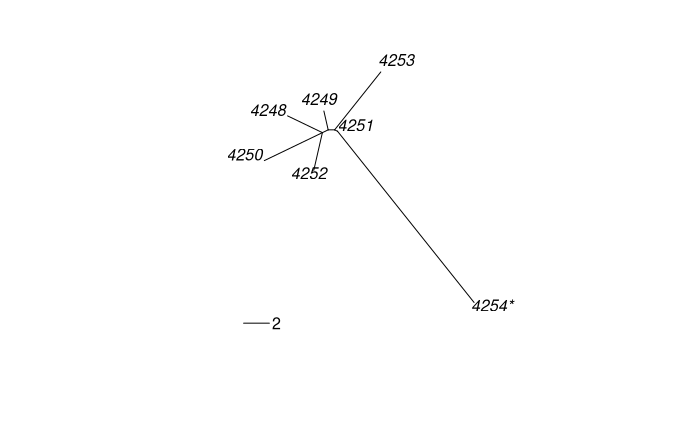

```r
patient_11_tree <-
  nj(dist(t(patient_11_matrix), upper = TRUE, diag = TRUE, method = "manhattan"))
patient_11_tree$tip.label[patient_11_tree$tip.label == "4254"] <- "4254*"

patient_13_tree <-
  nj(dist(t(patient_13_matrix), upper = TRUE, diag = TRUE, method = "manhattan"))
patient_13_tree$tip.label[patient_13_tree$tip.label == "4433"] <- "4433*"

patient_17_tree <-
  nj(dist(t(patient_17_matrix), upper = TRUE, diag = TRUE, method = "manhattan"))
patient_17_tree$tip.label[patient_17_tree$tip.label == "5-36"] <- "5-36*"

plot(patient_11_tree, type = "unrooted")
add.scale.bar()
```

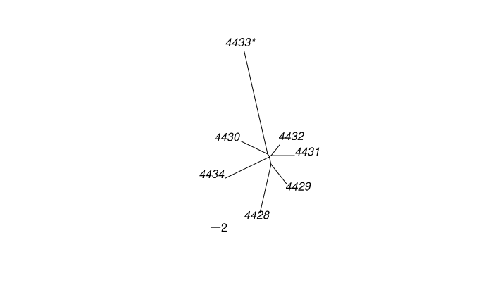

```r
plot(patient_13_tree, type = "unrooted")
add.scale.bar()
```

```r
plot(patient_17_tree, type = "unrooted")
add.scale.bar()
```

```r
save_plot(plot = {plot(patient_11_tree, type = "unrooted"); add.scale.bar()}, filename = "../docs/Figs/trees/p_11_tree.pdf")
save_plot(plot = {plot(patient_13_tree, type = "unrooted"); add.scale.bar()}, filename = "../docs/Figs/trees/p_13_tree.pdf")
```

[figure not shown]

```r
save_plot(plot = {plot(patient_17_tree, type = "unrooted"); add.scale.bar()}, filename = "../docs/Figs/trees/p_17_tree.pdf")
```

```r
# tidytree::as_tibble(patient_11_tree)
# list_tree <-
#   list(Patient_11 = unroot(phy = patient_11_tree),
#        Patient_13 = unroot(phy = patient_13_tree),
#        Patient_17 = unroot(phy = patient_17_tree))
#
# class(list_tree) <- "multiPhylo"
#
# ggtree(tr = list_tree, layout = "daylight") + # other layout: equal_angle
#   geom_tiplab(hjust = 0) +
#   geom_treescale() +
#   facet_wrap(~.id, scales = "free")

#
# ggtree(patient_11_tree, aes(x,y), layout = "eq") +
#   geom_text(aes(x = ifelse(x >= -2, x + 0.6, x - 0.6),
#                 label = c(patient_11_tree$tip.label, rep(NA, 5)))) +
#   # geom_tiplab2(offset = -0.6) +
#   geom_treescale(width = 1) +
#   # xlim(-10,10) +
#   # ylim(-3,16) +
#   theme_tree()
#
# ggtree(patient_11_tree, aes(x,y), layout = "eq") +
#   geom_tippoint() +
#   geom_tiplab2(hjust = 0, colour = "grey", fontface = "bold", family = "mono", size = 5) +
#   geom_tiplab2(hjust = 0, colour = "black", family = "mono", size = 5) +
#   geom_treescale(width = 1) +
#   expand_limits(x = 0, y = -5)+
#   theme_tree() +
#   geom_blank()
#
#
# ggtree(patient_13_tree, aes(x,y), layout = "day") +
#   geom_tippoint() +
#   geom_tiplab2(hjust = 0, colour = "grey", fontface = "bold", family = "mono", size = 5) +
#   geom_tiplab2(hjust = 0, colour = "black", family = "mono", size = 5) +
#   geom_treescale(width = 1) +
#   expand_limits(x = c(-6,11), y = c(-7, 20))+
#   theme_tree2() +
#   geom_blank()
```

# Mutation rates (rifampicin test)

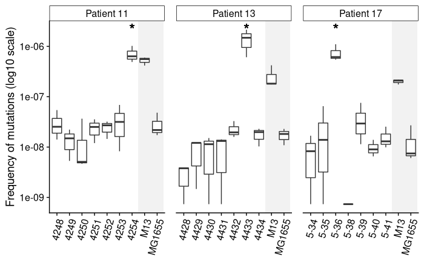

```r
mut_rate_df <- read_delim("~/longterm_abn/2019_three_patients/docs/Tables/20190706_all_rif_test.csv",
    "\t", escape_double = FALSE, trim_ws = TRUE)
mut_rate_df %>%
  mutate(Strain = factor(x = Strain, levels = unique(mut_rate_df$Strain)[c(1:7,10:24,8:9)])) %>%
  mutate(id = factor(paste(Patient, Strain, sep = "-"))) %>%
  mutate(Star = if_else(condition = Strain %in% mutators, true = "*", false = "")) %>%
  filter(Strain != "5-32") %>%
  group_by(Patient) %>%
  # if mutation rate == 0, then value is fixed
  # as half the minimum recovered value
  mutate(mut = if_else(condition = mut > 0, true = mut, false = min(.$mut[.$mut > 0]) / 2 )) %>%
  ungroup() %>%
  mutate(mut_log = log10(mut)) -> mut_rate_df

highlight_ctrl <-
  tibble(x_start = 7.5,
         x_end = 9.5,
         y_start = 0, y_end = Inf)

# get_label_from_id <- function(x){
#   x_bis <- str_replace(string = x, pattern = "[[:alpha:]]+_{0,1}[0-9]{0,2}-(.*)", replacement = "\\1")
#   return(x_bis)
# }

get_label_from_patient <- as_labeller(function(x){
  x_bis <- str_replace(string = x, pattern = "_", replacement = " ")
  return(x_bis)
})

# rif_plot <-
ggplot() +
  geom_blank(data = mut_rate_df, mapping = aes(y = mut, x = Strain)) + # sets the scales
  geom_rect(data = highlight_ctrl, aes(xmin = x_start, xmax = x_end, ymin = y_start, ymax = y_end),
            fill = "gray", alpha = 0.2) +
  geom_boxplot(data = mut_rate_df, mapping = aes(y = mut, x = Strain),
               outlier.shape = NA) +
  geom_text(data = mut_rate_df, aes(x = Strain, y = max(mut), label = Star), size = 7) +
  facet_grid(cols = vars(Patient), scales = "free_x", space = "free_x", labeller = get_label_from_patient) +
  ylab("Frequency of mutations (log10 scale)") +
  scale_y_log10() +
  theme(axis.title.x = element_blank(),
        axis.text.x = element_text(angle = 75, hjust = 1)) +
  theme(strip.background = element_rect(colour = "black", fill = "white")) +
  theme() +
  theme(panel.spacing = unit(1, "lines"))
```

```r
# rif_plot
# save_plot(filename = "~/Desktop/rif_test.pdf", plot = rif_plot, base_aspect_ratio = 2)
```

## Little stats

```r
for (i in 1:length(patients)){
  print(patients[i])
  print(mut_trans_tables[1:2,1:2,i])
  print(fisher.test(x = mut_trans_tables[1:2,1:2,i], alternative = "less"))
}
```

```
[1] "patient_11"
       transversion
mutator FALSE TRUE
  FALSE     6    8
  TRUE     12    0

    Fisher's Exact Test for Count Data

data:  mut_trans_tables[1:2, 1:2, i]
p-value = 0.001922
alternative hypothesis: true odds ratio is less than 1
95 percent confidence interval:
 0.0000000 0.3273639
sample estimates:
odds ratio
         0

[1] "patient_13"
       transversion
mutator FALSE TRUE
  FALSE    15   11
  TRUE     12    3

    Fisher's Exact Test for Count Data

data:  mut_trans_tables[1:2, 1:2, i]
p-value = 0.1332
alternative hypothesis: true odds ratio is less than 1
95 percent confidence interval:
 0.000000 1.426648
sample estimates:
odds ratio
   0.34969

[1] "patient_17"
       transversion
mutator FALSE TRUE
  FALSE    40   26
  TRUE     77    7

    Fisher's Exact Test for Count Data

data:  mut_trans_tables[1:2, 1:2, i]
p-value = 5.191e-06
alternative hypothesis: true odds ratio is less than 1
95 percent confidence interval:
 0.0000000 0.3262262
sample estimates:
odds ratio
 0.1418456
```

# Mice infections & Kaplan-Meier curves

```r
mice_infection <- read_delim("../data/mice_infections/mice_infection.csv",
                             "\t", escape_double = FALSE, trim_ws = TRUE)
mice_infection %>%
  mutate(clone = str_replace(string = mice_infection$clone, pattern = "P(5.*)", replacement = "\\1")) %>%
  filter(clone != "5-37") %>%
  identity() -> mice_infection


mice_infection %>%
  filter(patient != "patient_11") %>%
  group_by(patient, clone) %>%
  summarise(n_death = sum(time < max(time))) %>%
  # summarise(n_death = sum(n_death > 0) / n()) %>%
  identity() -> mice_infection_pheno
```

Homemade survival curve plotting

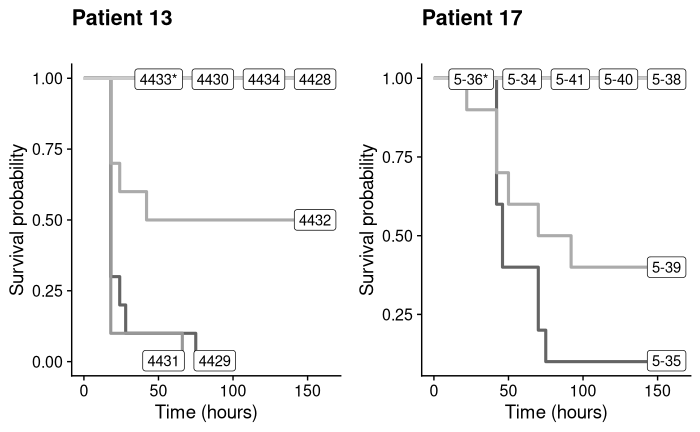

```r
mice_for_plot <- mice_infection
# adding time 0
for (i in 1:length(unique(mice_for_plot$clone))){
  curr_clone <- unique(mice_for_plot$clone)[i]
  curr_patient <- mice_for_plot$patient[mice_for_plot$clone == curr_clone][1]
  # print(curr_clone)
  curr_row <- c(0,0,0, curr_clone, curr_patient)
  mice_for_plot <-
    add_row(.data = mice_for_plot, time = 0, event = 0, mouse = 0, clone = curr_clone, patient = curr_patient)
}

mice_for_plot %>%
  arrange(time) %>%
  filter(patient != "patient_11" & patient != "ctrl") %>%
  mutate(clone = if_else(condition = clone %in% mutators, true = paste0(clone,"*"), false = clone)) %>%
  # filter(clone == "5-35") %>%
  group_by(clone) %>%
  mutate(lab = if_else(condition = time == max(time), true = clone, false = "")) %>%
  mutate(n_mouse = sum(mouse != 0)) %>%
  mutate(cum_event = cumsum(event)) %>%
  group_by(clone, time) %>%
  mutate(surv = (n_mouse[1] - max(cum_event)) / n_mouse[1]) %>%
  slice(1) %>%
  select(-event, -n_mouse, - cum_event) %>%
  ungroup() %>%
  identity() -> mice_for_plot

  ggplot(data = mice_for_plot[mice_for_plot$patient == "patient_13", ],
         aes(x = time, y = surv, group = clone)) +
  geom_step(aes(colour = clone), size = 1.1) +
  geom_label_repel(mapping = aes(label = lab),
                   direction = "x",
                   point.padding = 0, max.iter = 1e4, min.segment.length = 100) +
  scale_color_grey() +
  theme(legend.position = "none") +
  xlab("Time (hours)")   +
  ylab("Survival probability") +
  ggtitle(label = "Patient 13", subtitle = "") -> mice_13

  ggplot(data = mice_for_plot[mice_for_plot$patient == "patient_17", ],
         aes(x = time, y = surv, group = clone)) +
  geom_step(aes(colour = clone), size = 1.1) +
  geom_label_repel(mapping = aes(label = lab),
                   direction = "x",
                   point.padding = 0, max.iter = 1e4, min.segment.length = 100) +
  scale_color_grey() +
  theme(legend.position = "none") +
  xlab("Time (hours)") +
  ylab("Survival probability") +
  ggtitle(label = "Patient 17", subtitle = "") -> mice_17

  cowplot::plot_grid(mice_13, mice_17, labels = "")
```

## rpoS mutants competition

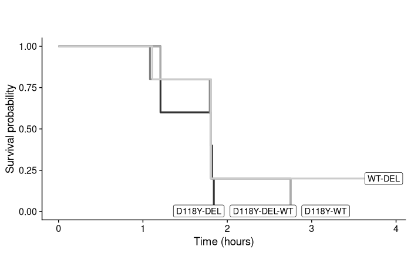

```r
mice_compet <- read_delim("../data/mice_infections/mice_compet_rpoS_infection.csv",
                             "\t", escape_double = FALSE, trim_ws = TRUE)
manip_start <- lubridate::dmy_hms("07-02-2013 14:00:00")

mice_compet %>%
  filter(! clone %in% c("CFT073", "K12")) %>%
  mutate(date = (lubridate::dmy_hms(paste(date, hour_min, sep = " ")))) %>%
  mutate(time = as.numeric(date - manip_start)) %>%
  identity() -> mice_compet

compet_for_plot <- mice_compet
# adding time 0
for (i in 1:length(unique(compet_for_plot$clone))){
  curr_clone <- unique(compet_for_plot$clone)[i]
  curr_row <- c(0,0,0, curr_clone)
  compet_for_plot <-
    add_row(.data = compet_for_plot, time = 0, event = 0, mouse = 0, clone = curr_clone)
}

compet_for_plot %>%
  arrange(time) %>%
  # filter(patient != "patient_11" & patient != "ctrl") %>%
  # mutate(clone = if_else(condition = clone %in% mutators, true = paste0(clone,"*"), false = clone)) %>%
  # filter(clone == "5-35") %>%
  group_by(clone) %>%
  mutate(lab = if_else(condition = time == max(time), true = clone, false = "")) %>%
  mutate(n_mouse = sum(mouse != 0)) %>%
  mutate(cum_event = cumsum(event)) %>%
  group_by(clone, time) %>%
  mutate(surv = (n_mouse[1] - max(cum_event)) / n_mouse[1]) %>%
  slice(1) %>%
  select(-event, -n_mouse, - cum_event) %>%
  ungroup() %>%
  identity() -> compet_for_plot

ggplot(data = compet_for_plot,
       aes(x = time, y = surv, group = clone)) +
  geom_step(aes(colour = clone), size = 1.1) +
  geom_label_repel(mapping = aes(label = lab),
                   direction = "x",
                   point.padding = 0, max.iter = 1e4, min.segment.length = 100) +
  scale_color_grey() +
  theme(legend.position = "none") +
  xlab("Time (hours)") +
  ylab("Survival probability") +
  ggtitle(label = "", subtitle = "") -> compet_survplot

compet_survplot
```

```r
# fit_compet <- survival::survfit(survival::Surv(time, event) ~ clone, data = mice_compet[,])
# plot_surv_compet <- survminer::ggsurvplot(fit = fit_compet, data = mice_compet)[[1]]
# plot_surv_compet + xlab("Time (hours)")
```

## Association study

### associations at gene level

No strat

```r
large_del_inter_pattern <- "[–\\/\\[]" # the / is a sign of intergenic_mutation

all_mut %>%
  mutate(gene_name = str_replace(string = gene_name,
                                 pattern = "(.*)_[0-9]{1,2}$",
                                 replacement = "\\1")) %>%
  mutate(gene_name = str_replace(string = gene_name,
                               pattern = "-",
                               replacement = "_")) %>%
  filter((type == "SNP" & snp_type != "intergenic") |
           (type %in% c("DEL", "INS")) &
           !str_detect(string = gene_name, pattern = large_del_inter_pattern)) %>%
  select(patient, subclon, gene_name, gene_product, type) %>%
  mutate(clone = str_split(string = subclon, pattern = "\\|")) %>%
  mutate(gene_name = str_split(string = gene_name, pattern = ";")) %>%
  mutate(mut = 1) %>%
  unnest_longer(col = clone) %>%
  unnest_longer(col = gene_name) %>%
  select(-subclon, -type, -gene_product, -patient) %>%
  distinct() %>%
  identity() -> all_snp_cov_long

reference_clones <-
  data.frame(clone = c("4250", "4429", "5-35"),
            stringsAsFactors = FALSE)

all_snp_cov_long %>%
  pivot_wider(names_from = gene_name, values_from = mut, values_fill = list(mut = 0), values_fn = list(mut = unique)) %>%
  bind_rows(reference_clones) %>%
  identity() -> all_snp_cov_wide

all_snp_cov_wide[is.na.data.frame(all_snp_cov_wide)] <- 0

mice_infection %>%
  filter(patient == "patient_17") %>%
  filter(clone != "5-37") %>%
  # select_if(.predicate = function(col) length(unique(col) > 1)) #does not work...
  left_join(y = all_snp_cov_wide, by = c("clone")) %>%
  identity() -> mice_infection_cov_gene

sup_one <- function(x) length(unique(x)) > 1


mice_infection_cov_gene <-
  mice_infection_cov_gene[ ,sapply(X = mice_infection_cov_gene, FUN = sup_one )]

# Regression time
gene_covariates <- names(mice_infection_cov_gene)[c(-1,-2,-3,-4)]


formulas_gene <- sapply(gene_covariates,
                        function(x) as.formula(paste('Surv(time, event)~', x)))




cox_gene_list <- suppressWarnings(
  lapply(X = formulas_gene, FUN = function(x) coxph(formula = x, data = mice_infection_cov_gene))
)

p_gene_list <-
  unlist(lapply(X = cox_gene_list, FUN = function(x) summary(x)$wald["pvalue"]))

summary(p_gene_list)
```

```
     Min.   1st Qu.    Median      Mean   3rd Qu.      Max.
0.0000002 0.9973593 0.9973593 0.9149691 0.9973593 0.9977351
```

```r
p_gene_list_corrected <- p.adjust(p = p_gene_list, method = "fdr") # fdr == BH
summary(p_gene_list_corrected)
```

```
     Min.   1st Qu.    Median      Mean   3rd Qu.      Max.
0.0000043 0.9977351 0.9977351 0.9162291 0.9977351 0.9977351
```

```r
p_gene_threshold <- 0.001

# p_gene_list_corrected[p_gene_list_corrected <= p_gene_threshold]
# cox_gene_list[p_gene_list_corrected <= p_gene_threshold]
```

Stratification by PCA is not a good idea!

```r
large_del_inter_pattern <- "[–\\/\\[]" # the / is a sign of intergenic_mutation

all_mut %>%
  mutate(gene_name = str_replace(string = gene_name,
                                 pattern = "(.*)_[0-9]{1,2}$",
                                 replacement = "\\1")) %>%
  mutate(gene_name = str_replace(string = gene_name,
                               pattern = "-",
                               replacement = "_")) %>%
  filter((type == "SNP" & snp_type != "intergenic") |
           (type %in% c("DEL", "INS")) &
           !str_detect(string = gene_name, pattern = large_del_inter_pattern)) %>%
  select(patient, subclon, gene_name, gene_product, type) %>%
  mutate(clone = str_split(string = subclon, pattern = "\\|")) %>%
  mutate(gene_name = str_split(string = gene_name, pattern = ";")) %>%
  mutate(mut = 1) %>%
  unnest_longer(col = clone) %>%
  unnest_longer(col = gene_name) %>%
  select(-subclon, -type, -gene_product, -patient) %>%
  distinct() %>%
  identity() -> all_snp_cov_long

reference_clones <-
  data.frame(clone = c("4250", "4429", "5-35"),
            stringsAsFactors = FALSE)

all_snp_cov_long %>%
  pivot_wider(names_from = gene_name, values_from = mut, values_fill = list(mut = 0), values_fn = list(mut = unique)) %>%
  bind_rows(reference_clones) %>%
  identity() -> all_snp_cov_wide

all_snp_cov_wide[is.na.data.frame(all_snp_cov_wide)] <- 0

mice_infection %>%
  filter(patient == "patient_17") %>%
  filter(clone != "5-37") %>%
  # select_if(.predicate = function(col) length(unique(col) > 1)) #does not work...
  left_join(y = all_snp_cov_wide, by = c("clone")) %>%
  identity() -> mice_infection_cov_gene

sup_one <- function(x) length(unique(x)) > 1


mice_infection_cov_gene <-
  mice_infection_cov_gene[ ,sapply(X = mice_infection_cov_gene, FUN = sup_one )]


snp_pca <- prcomp(x = (all_snp_cov_wide[, -1]))
snp_pca <- data.frame(clone = all_snp_cov_wide$clone,
                      snp_pca$x[,1:3],
                      stringsAsFactors = FALSE)
mice_infection_cov_gene <-
  mice_infection_cov_gene %>%
    left_join(snp_pca, by = c("clone"))

# Regression time

gene_covariates <- names(mice_infection_cov_gene)[c(4:137)]


formulas_gene <- sapply(gene_covariates,
                        function(x) as.formula(paste('Surv(time, event)~', x, "+PC1+PC2+PC3")))

cox_gene_list <- suppressWarnings(
  lapply(X = formulas_gene, FUN = function(x) coxph(formula = x, data = mice_infection_cov_gene))
)

p_gene_list <-
  unlist(lapply(X = cox_gene_list, FUN = function(x) coefficients(summary(x))[,5][1]))

summary(p_gene_list)
```

```
   Min. 1st Qu.  Median    Mean 3rd Qu.    Max.
 0.0000  0.9991  0.9991  0.9544  0.9992  0.9999
```

```r
p_gene_list_corrected <- p.adjust(p = p_gene_list, method = "fdr") # fdr == BH
summary(p_gene_list_corrected)
```

```
   Min. 1st Qu.  Median    Mean 3rd Qu.    Max.
 0.0000  0.9999  0.9999  0.9551  0.9999  0.9999
```

```r
p_gene_threshold <- 0.01

# p_gene_list_corrected[p_gene_list_corrected <= p_gene_threshold]
# cox_gene_list[p_gene_list_corrected <= p_gene_threshold]
```

Using only genes that are target of within sample convergence

```r
all_mut %>%
  mutate(gene_name = str_replace(string = gene_name,
                                 pattern = "(.*)_[0-9]{1,2}$",
                                 replacement = "\\1")) %>%
  mutate(gene_name = str_replace(string = gene_name,
                               pattern = "-",
                               replacement = "_")) %>%
  filter((type == "SNP" & snp_type != "intergenic") |
           (type %in% c("DEL", "INS")) &
           !str_detect(string = gene_name, pattern = large_del_inter_pattern)) %>%
  select(patient, subclon, gene_name, gene_product, type) %>%
  group_by(patient, gene_name) %>%
  mutate(within_n = n()) %>%
  filter(within_n > 1) %>%
  ungroup() %>%
  mutate(clone = str_split(string = subclon, pattern = "\\|")) %>%
  mutate(gene_name = str_split(string = gene_name, pattern = ";")) %>%
  mutate(mut = 1) %>%
  unnest_longer(col = clone) %>%
  unnest_longer(col = gene_name) %>%
  select(-subclon, -type, -gene_product, -patient, -within_n) %>%
  distinct() %>%
  pivot_wider(names_from = gene_name, values_from = mut, values_fill = list(mut = 0), values_fn = list(mut = unique)) %>%
  bind_rows(reference_clones) %>%
  mutate_all(.funs = function(x) ifelse(is.na(x), 0, x)) %>%
  identity() -> all_mut_within_wide

mice_infection %>%
  filter(patient == "patient_13") %>% # patient_17
  filter(clone != "5-37") %>%
  # select_if(.predicate = function(col) length(unique(col) > 1)) #does not work...
  left_join(y = all_mut_within_wide, by = c("clone")) %>%
  mutate_all(.funs = function(x) ifelse(is.na(x), 0, x)) %>%
  identity() -> mice_infection_cov_within

sup_one <- function(x) length(unique(x)) > 1
mice_infection_cov_within <-
  mice_infection_cov_within[ ,sapply(X = mice_infection_cov_within, FUN = sup_one )]

# Regression time
within_covariates <- names(mice_infection_cov_within)[c(-1,-2,-3,-4)]


formulas_within <- sapply(within_covariates,
                        function(x) as.formula(paste('Surv(time, event)~', x)))

cox_within_list <- suppressWarnings(
  lapply(X = formulas_within, FUN = function(x) coxph(formula = x, data = mice_infection_cov_within))
)

p_within_list <-
  unlist(lapply(X = cox_within_list, FUN = function(x) summary(x)$wald["pvalue"]))
summary(p_within_list)
```

```
     Min.   1st Qu.    Median      Mean   3rd Qu.      Max.
0.0000027 0.0000027 0.0398262 0.3838251 0.9969801 0.9969801
```

```r
p_within_list_corrected <- p.adjust(p = p_within_list, method = "fdr") # fdr == BH
summary(p_within_list_corrected)
```

```
     Min.   1st Qu.    Median      Mean   3rd Qu.      Max.
0.0000072 0.0000072 0.0700078 0.3913722 0.9969801 0.9969801
```

```r
p_within_threshold <- 0.01

# p_within_list_corrected[p_within_list_corrected <= p_within_threshold]
# cox_within_list[p_within_list_corrected <= p_within_threshold]
```

# rpoS mutants survival

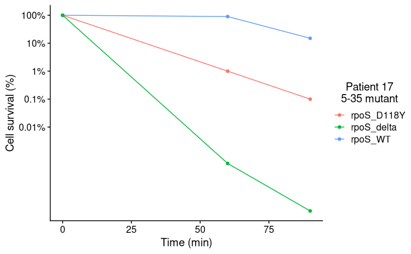

```r
rpos_mut <-
  read_tsv(file = "../data/rpoS/rpos_mutants_surv.csv", col_names = TRUE)
ggplot(data = rpos_mut,
       aes(x = time, y = surv, group = mutant, colour = mutant)) +
  geom_line() +
  geom_point() +
  # scale_y_log10(label = c("0", "0.1%","1%","10%","100%"), breaks = c(0, 0.1, 1, 10,100)) +
  scale_y_log10(label = c("0", "0.01%", "0.1%","1%","10%","100%"), breaks = c(0, 0.01, 0.1, 1, 10,100)) +
  xlab("Time (min)") +
  ylab("Cell survival (%)") +
  labs(colour = "Patient 17\n5-35 mutant") +
  theme(legend.title.align=0.5) +
  # ylim(c(0.1, 1e2))
  geom_blank()
```

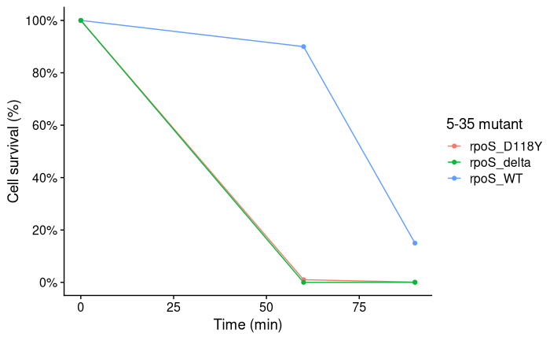

```r
ggplot(data = rpos_mut,
       aes(x = time, y = surv, group = mutant, colour = mutant)) +
  geom_line() +
  geom_point() +
  scale_y_continuous(label = paste0(seq(0,100,20), "%"), breaks = seq(0,100,20)) +
  xlab("Time (min)") +
  ylab("Cell survival (%)") +
  labs(colour = "5-35 mutant") +
  # ylim(c(0.1, 1e2))
  geom_blank()
```